# PCR and PLS Regression

### Sunah Park

This markdown file is created by Sunah Park for extended lab exercises in the book *An Introduction to Statistical Learning with Applications in R* [(ISLR)](https://www-bcf.usc.edu/~gareth/ISL/ISLR%20First%20Printing.pdf).

### Setup for code chunks

```r
rm(list=ls())
# default r markdown global options in document
knitr::opts_chunk$set(
   ########## Text results ##########
    echo=TRUE,
    warning=FALSE, # to preserve warnings in the output
    error=FALSE, # to preserve errors in the output
    message=FALSE, # to preserve messages
    strip.white=TRUE, # to remove the white lines in the beginning or end of a source chunk in the output

    ########## Cache ##########
    cache=TRUE,

    ########## Plots ##########
    fig.path="", # prefix to be used for figure filenames
    fig.width=8,
    fig.height=6,
    dpi=200
)
```

```r
library(pls) # pcr() function, plsr() function
library(ISLR)
library(ggplot2)
```

```r
head(Hitters,3)
```

```
##                AtBat Hits HmRun Runs RBI Walks Years CAtBat CHits CHmRun
## -Andy Allanson   293   66     1   30  29    14     1    293    66      1
## -Alan Ashby      315   81     7   24  38    39    14   3449   835     69
## -Alvin Davis     479  130    18   66  72    76     3   1624   457     63
##                CRuns CRBI CWalks League Division PutOuts Assists Errors
## -Andy Allanson    30   29     14      A        E     446      33     20
## -Alan Ashby      321  414    375      N        W     632      43     10
## -Alvin Davis     224  266    263      A        W     880      82     14
##                Salary NewLeague
## -Andy Allanson     NA         A
## -Alan Ashby       475         N
## -Alvin Davis      480         A
```

```r
Hitters<-na.omit(Hitters)
```

## **Principal Components Regression**

Principal components regression (PCR) can be performed using the pcr() function, which is part of the pls library. We now apply PCR to the Hitters data, in order to predict Salary. The syntax for the pcr() function is similar to that for lm(), with a few additional options. Setting scale=TRUE has the effect of standardizing each predictor prior to generating the principal components, so that the scale on which each variable is measured will not have an effect. Setting validation=“CV” causes pcr() to compute the ten-fold cross-validation error for each possible value of M, the number of principal components used. The resulting fit can be examined using summary().

```r
set.seed(1)
pcr.fit<-pcr(Salary~., data=Hitters, scale=TRUE, validation="CV")
summary(pcr.fit)
```

```
## Data:    X dimension: 263 19
##  Y dimension: 263 1
## Fit method: svdpc
## Number of components considered: 19
##
## VALIDATION: RMSEP
## Cross-validated using 10 random segments.
##        (Intercept)  1 comps  2 comps  3 comps  4 comps  5 comps  6 comps
## CV             452    352.4    349.7    349.2    346.6    341.6    341.0
## adjCV          452    352.0    349.4    348.9    346.3    341.3    340.4
##        7 comps  8 comps  9 comps  10 comps  11 comps  12 comps  13 comps
## CV       342.0    342.6    343.4     345.1     345.7     348.9     348.6
## adjCV    341.3    341.8    342.6     344.0     344.6     347.7     347.3
##        14 comps  15 comps  16 comps  17 comps  18 comps  19 comps
## CV        343.0     345.4     336.6     338.5     334.8     337.6
## adjCV     341.5     343.9     335.1     336.8     333.1     335.7
##
## TRAINING: % variance explained
##         1 comps  2 comps  3 comps  4 comps  5 comps  6 comps  7 comps
## X         38.31    60.16    70.84    79.03    84.29    88.63    92.26
## Salary    40.63    41.58    42.17    43.22    44.90    46.48    46.69
##         8 comps  9 comps  10 comps  11 comps  12 comps  13 comps  14 comps
## X         94.96    96.28     97.26     97.98     98.65     99.15     99.47
## Salary    46.75    46.86     47.76     47.82     47.85     48.10     50.40
##         15 comps  16 comps  17 comps  18 comps  19 comps
## X          99.75     99.89     99.97     99.99    100.00
## Salary     50.55     53.01     53.85     54.61     54.61
```

The CV score is provided for each possible number of components, ranging from M=0 onwards. Note that pcr() reports the root mean squared error; in order to obtain the usual MSE, we must square this quantity. One can also plot the cross-validation scores using the validationplot() function. Using val.type=“MSEP” will cause the cross-validation MSE to be plotted.

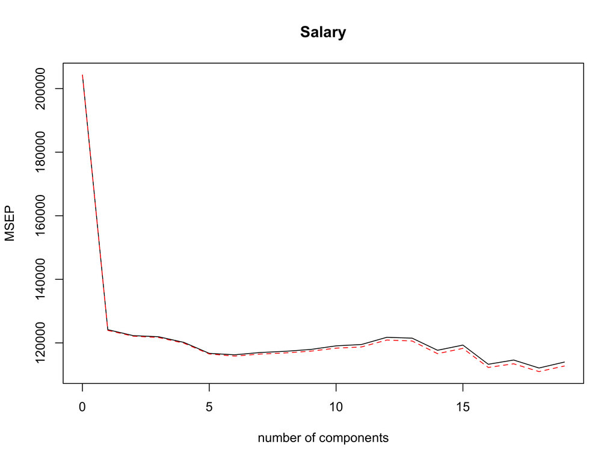

```r
validationplot(pcr.fit, val.type="MSEP")
```

```r
summary(pcr.fit)
```

```
## Data:    X dimension: 263 19
##  Y dimension: 263 1
## Fit method: svdpc
## Number of components considered: 19
##
## VALIDATION: RMSEP
## Cross-validated using 10 random segments.
##        (Intercept)  1 comps  2 comps  3 comps  4 comps  5 comps  6 comps
## CV             452    352.4    349.7    349.2    346.6    341.6    341.0
## adjCV          452    352.0    349.4    348.9    346.3    341.3    340.4
##        7 comps  8 comps  9 comps  10 comps  11 comps  12 comps  13 comps
## CV       342.0    342.6    343.4     345.1     345.7     348.9     348.6
## adjCV    341.3    341.8    342.6     344.0     344.6     347.7     347.3
##        14 comps  15 comps  16 comps  17 comps  18 comps  19 comps
## CV        343.0     345.4     336.6     338.5     334.8     337.6
## adjCV     341.5     343.9     335.1     336.8     333.1     335.7
##
## TRAINING: % variance explained
##         1 comps  2 comps  3 comps  4 comps  5 comps  6 comps  7 comps
## X         38.31    60.16    70.84    79.03    84.29    88.63    92.26
## Salary    40.63    41.58    42.17    43.22    44.90    46.48    46.69
##         8 comps  9 comps  10 comps  11 comps  12 comps  13 comps  14 comps
## X         94.96    96.28     97.26     97.98     98.65     99.15     99.47
## Salary    46.75    46.86     47.76     47.82     47.85     48.10     50.40
##         15 comps  16 comps  17 comps  18 comps  19 comps
## X          99.75     99.89     99.97     99.99    100.00
## Salary     50.55     53.01     53.85     54.61     54.61
```

However, from the plot we also see that the CV error is roughly the same when only one component is included in the model. This suggests that a model that uses just a small number of components might suffice.

The summary() function also provides the percentage of variance explained in the predictors and in the response using different numbers of components. Setting M=1 only captures 38,31% of all the variance, or information, in the predictors. In contrast, using M=6 increases the value to 88.63%. If we were to use all M=p=19 components, this would increase to 100%.

We now perform PCR on the training data and evaluate its test set performance.

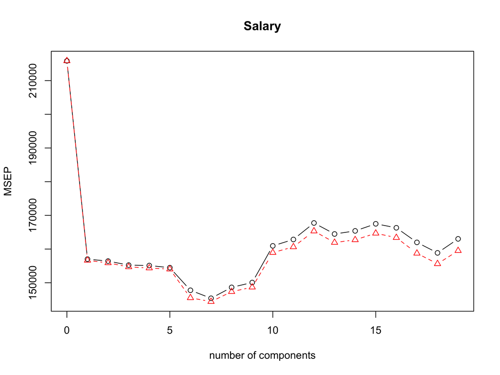

```r
x<-model.matrix(Salary~., data=Hitters)[,-1]
y<-Hitters$Salary

set.seed(1)
train<-sample(1:nrow(x),size=nrow(x)/2)
test<--train
y.test<-y[test]

pcr.fit<-pcr(Salary~., data=Hitters, subset=train, scale=TRUE, validation="CV")
validationplot(pcr.fit, val.type="MSEP", type="b")
```

We find that the lowest cross-validation error occurs when M=7 component are used.

```r
pcr.pred<-predict(pcr.fit, x[test,], ncomp=7)
mean((pcr.pred-y.test)^2)
```

```
## [1] 96556.22
```

This test set MSE is competitive with the results obtained using ridge regression and the lasso. However, as a result of the way PCR is implemented, the final model is more difficult to interpret because it does not perform any kind of variable selection or even direclty produce coefficient estimates.

Now we fit PCR on the full data set, using M=7, the number of components identified by cross-validation.

```r
pcr.fit<-pcr(y~x, scale=TRUE, ncomp=7)
summary(pcr.fit)
```

```
## Data:    X dimension: 263 19
##  Y dimension: 263 1
## Fit method: svdpc
## Number of components considered: 7
## TRAINING: % variance explained
##    1 comps  2 comps  3 comps  4 comps  5 comps  6 comps  7 comps
## X    38.31    60.16    70.84    79.03    84.29    88.63    92.26
## y    40.63    41.58    42.17    43.22    44.90    46.48    46.69
```

## **Partial Least Squares**

We implement partial least squares(PLS) using the plsr() function.

```r
set.seed(1)
pls.fit<-plsr(Salary~., data=Hitters, subset=train, scale=TRUE, validation="CV")
summary(pls.fit)
```

```
## Data:    X dimension: 131 19
##  Y dimension: 131 1
## Fit method: kernelpls
## Number of components considered: 19
##
## VALIDATION: RMSEP
## Cross-validated using 10 random segments.
##        (Intercept)  1 comps  2 comps  3 comps  4 comps  5 comps  6 comps
## CV           464.6    394.2    391.5    393.1    395.0    415.0    424.0
## adjCV        464.6    393.4    390.2    391.1    392.9    411.5    418.8
##        7 comps  8 comps  9 comps  10 comps  11 comps  12 comps  13 comps
## CV       424.5    415.8    404.6     407.1     412.0     414.4     410.3
## adjCV    418.9    411.4    400.7     402.2     407.2     409.3     405.6
##        14 comps  15 comps  16 comps  17 comps  18 comps  19 comps
## CV        406.2     408.6     410.5     408.8     407.8     410.2
## adjCV     401.8     403.9     405.6     404.1     403.2     405.5
##
## TRAINING: % variance explained
##         1 comps  2 comps  3 comps  4 comps  5 comps  6 comps  7 comps
## X         38.12    53.46    66.05    74.49    79.33    84.56    87.09
## Salary    33.58    38.96    41.57    42.43    44.04    45.59    47.05
##         8 comps  9 comps  10 comps  11 comps  12 comps  13 comps  14 comps
## X         90.74    92.55     93.94     97.23     97.88     98.35     98.85
## Salary    47.53    48.42     49.68     50.04     50.54     50.78     50.92
##         15 comps  16 comps  17 comps  18 comps  19 comps
## X          99.11     99.43     99.78     99.99    100.00
## Salary     51.04     51.11     51.15     51.16     51.18
```

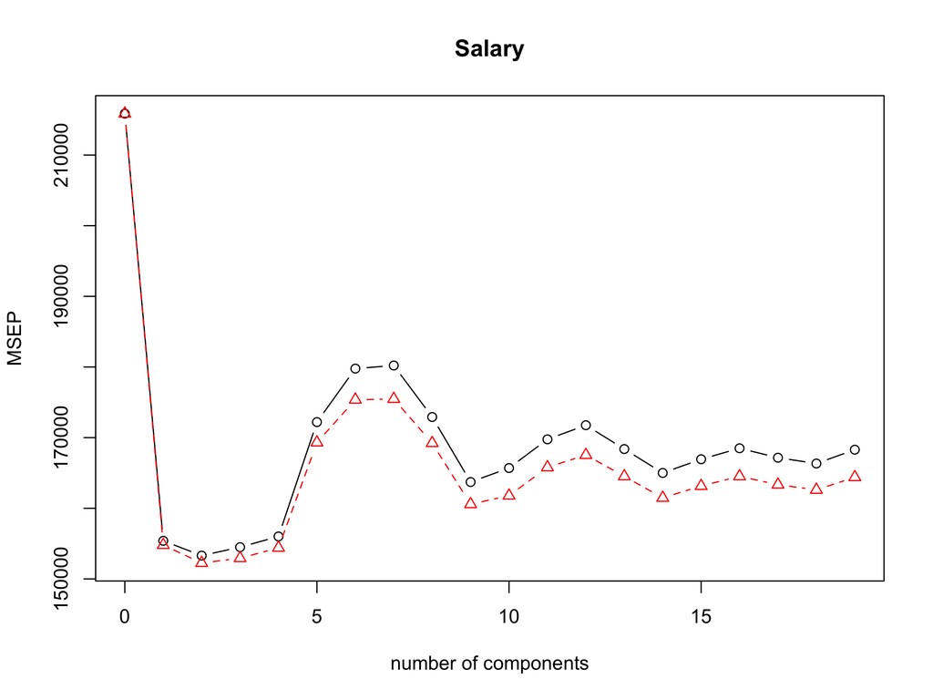

```r
validationplot(pls.fit, val.type="MSEP", type="b")
```

The lowest cross-validation error occurs when only M=2 partial least squares directions are used.

```r
pls.pred<-predict(pls.fit, x[test,], ncomp=2)
mean((pls.pred-y.test)^2)
```

```
## [1] 101417.5
```

The test MSE is comparable to but slightly higher than the test MSE obtained using PCR.

Finally, we perform PLS using the full data set, using M=2, the number of components identified by cross-validation.

```r
pls.fit<-plsr(y~x, scale=TRUE, ncomp=2)
summary(pls.fit)
```

```
## Data:    X dimension: 263 19
##  Y dimension: 263 1
## Fit method: kernelpls
## Number of components considered: 2
## TRAINING: % variance explained
##    1 comps  2 comps
## X    38.08    51.03
## y    43.05    46.40
```

Notice that the percentage of variance in Salary that two-component PLS fit explains 46.4% is almost as much as that explained using the final seven-component model PCR fit, 46.69%. This is because PCR only attempts to maximize the amount of variance explained in the predictors, while PLS searches for directions that explain variance in both the predictors and the response.